# Lecture 3

## Data Wrangling

- the combined process of data pre-processing and data transformation
- data pre-processing is the stage of cleaning data (e.g. empty values, repeated values)
- data transformation is the convertion of raw data to a useful data format

## Data Frames

What if we have data on all the company’s customers, including information like their name, birthday, contract duration, etc. What would be the best structure to store all these data?

**Is it a matrix?** Matrices have a square structure that allows for quick comparisons acros columns and rows. This is good for anylsis. However, it can only store 1 data type. All our data will be stored as characters!

**Is it a list?** A list is flexible enough to allow for multiple data types. However, it lacks the square structure that a matrix has. It is hence more difficult to make comparisons or search in a list.

The ideal structure in this case is the **data frame**. Similar to the data frame structure in Python, it is a happy mixture of both the list and matrix data structures.

### Working with Data Frames

- each column contains values about a specific attribute of the data
- each row contains all information about a specific instance of the data
- within a column, the data type is the same
- between different columns, the data type can be different
- can be thought of as a list of vectors

Creating the data frame manually:

```r
# method 1
Name = c("James", "Joe", "Janice", "Jessica")
Position = c("CEO", "VF", "Manager", "Clerk")
Gender = c("M", "M", "F", "F")
Salary = c(30000, 13000, 9800, 3500)
employees = data.frame(Name, Position, Gender, Salary)

# method 2
employees = data.frame(Name=c("James", "Joe", "Janice", "Jessica"),
                        Position=c("CEO", "VF", "Manager", "Clerk"),
                        Gender=c("M", "M", "F", "F"),
                        Salary=c(30000, 13000, 9800, 3500))

employees
```

```
##      Name Position Gender Salary
## 1   James      CEO      M  30000
## 2     Joe       VF      M  13000
## 3  Janice  Manager      F   9800
## 4 Jessica    Clerk      F   3500
```

Read from an existing file:

```r
df = read.csv("./Data/SRX_Data.csv")
class(df)
```

```
## [1] "data.frame"
```

### Accessing a Data Frame

```r
# single square bracket -> returns a data frame
employees[1]
```

```
##      Name
## 1   James
## 2     Joe
## 3  Janice
## 4 Jessica
```

```r
class(employees[1])
```

```
## [1] "data.frame"
```

```r
# double square brackets -> returns a vector
employees[[1]]
```

```
## [1] "James"   "Joe"     "Janice"  "Jessica"
```

```r
is.vector(employees[[1]])
```

```
## [1] TRUE
```

```r
# dollar sign
employees$Position
```

```
## [1] "CEO"     "VF"      "Manager" "Clerk"
```

```r
is.vector(employees$Position)
```

```
## [1] TRUE
```

```r
# indexing
employees[2,3]
```

```
## [1] "M"
```

```r
employees[2, ]
```

```
##   Name Position Gender Salary
## 2  Joe       VF      M  13000
```

### Naming

To facilitate searching, you can name the rows, provided all row names are unique.

```r
rownames(employees) = employees$Name
employees
```

```
##            Name Position Gender Salary
## James     James      CEO      M  30000
## Joe         Joe       VF      M  13000
## Janice   Janice  Manager      F   9800
## Jessica Jessica    Clerk      F   3500
```

```r
# rows can then be accessed by their names
employees["Joe", "Salary"]
```

```
## [1] 13000
```

### Removing Columns

```r
employees$Name = NULL
employees
```

```
##         Position Gender Salary
## James        CEO      M  30000
## Joe           VF      M  13000
## Janice   Manager      F   9800
## Jessica    Clerk      F   3500
```

### Viewing Data Frames

- type View(df) into the console
- click on the table icon next to the df object in the environment tab

### Structure Information

```r
# dimensions
dim(employees)
```

```
## [1] 4 3
```

```r
# structure
str(employees)
```

```
## 'data.frame':    4 obs. of  3 variables:
##  $ Position: chr  "CEO" "VF" "Manager" "Clerk"
##  $ Gender  : chr  "M" "M" "F" "F"
##  $ Salary  : num  30000 13000 9800 3500
```

```r
# summary
summary(employees) # provides some basic statistics
```

```
##    Position            Gender              Salary
##  Length:4           Length:4           Min.   : 3500
##  Class :character   Class :character   1st Qu.: 8225
##  Mode  :character   Mode  :character   Median :11400
##                                        Mean   :14075
##                                        3rd Qu.:17250
##                                        Max.   :30000
```

## Manipulating Data Frames

```r
companies = read.csv("./Data/Largest Companies in the World.csv")
summary(companies)
```

```
##  ï..Global.Rank     Company          Sales...billion. Profits...billion.
##  Min.   :   1.0   Length:1924        Min.   :  0.00   Min.   :-24.500
##  1st Qu.: 500.8   Class :character   1st Qu.:  4.10   1st Qu.:  0.300
##  Median : 997.5   Mode  :character   Median :  9.00   Median :  0.600
##  Mean   : 997.2                      Mean   : 19.27   Mean   :  1.226
##  3rd Qu.:1494.2                      3rd Qu.: 18.43   3rd Qu.:  1.200
##  Max.   :1999.0                      Max.   :469.20   Max.   : 44.900
##  Assets...billion.  Market.Value...billion.   Country
##  Min.   :   1.000   Min.   :  0.00          Length:1924
##  1st Qu.:   9.675   1st Qu.:  5.30          Class :character
##  Median :  19.250   Median :  9.60          Mode  :character
##  Mean   :  79.508   Mean   : 19.56
##  3rd Qu.:  45.800   3rd Qu.: 19.20
##  Max.   :3226.200   Max.   :416.60
##   Continent           Location
##  Length:1924        Length:1924
##  Class :character   Class :character
##  Mode  :character   Mode  :character
##
##
##
```

### Maxima / Minima

```r
# finding extreme values
max(companies$Assets...billion.)
```

```
## [1] 3226.2
```

```r
min(companies$Assets...billion.)
```

```
## [1] 1
```

```r
range(companies$Assets...billion.) # finds both
```

```
## [1]    1.0 3226.2
```

```r
# finding position of extreme values in the data frame
idx = which.max(companies$Assets...billion.) # gives the row number
companies[idx, "Company"]
```

```
## [1] "Fannie Mae"
```

### Sort

```r
# top 10
sorter = order(companies$Assets...billion., decreasing=T)
companies_sorted = companies[sorter, ]
head(companies_sorted, 10)$Company
```

```
##  [1] "Fannie Mae"               "ICBC"
##  [3] "HSBC Holdings"            "Mitsubishi UFJ Financial"
##  [5] "Deutsche Bank"            "BNP Paribas"
##  [7] "CrÃƒÂ©dit Agricole"       "Barclays"
##  [9] "JPMorgan Chase"           "China Construction Bank"
```

### Count

```r
# returns table object with the counts stored as values
continents = table(companies$Continent)

# convert to df for convenience
continents = as.data.frame((continents))

continents
```

```
##            Var1 Freq
## 1        Africa   25
## 2          Asia  719
## 3        Europe  459
## 4 North America  629
## 5       Oceania   43
## 6 South America   49
```

### Filter

```r
condition = companies$Continent == "Asia" &
              companies$Profits...billion. >= 30
result = companies[condition, ]

head(result)
```

```
##   ï..Global.Rank                 Company Sales...billion. Profits...billion.
## 1              1                    ICBC            134.8               37.8
## 2              2 China Construction Bank            113.1               30.6
##   Assets...billion. Market.Value...billion. Country Continent
## 1            2813.5                   237.3   China      Asia
## 2            2241.0                   202.0   China      Asia
##                Location
## 1 (35.86166,104.195397)
## 2 (35.86166,104.195397)
```

### Average

```r
mean(companies$Market.Value...billion.)
```

```
## [1] 19.55816
```

## Package ‘dplyr’

‘dplyr’ is a powerful package that helps to streamline a lot of data manipulation.

```r
library("dplyr")
```

### Filter

```r
# don't have to repeat companies in the logical operator
set1 = filter(companies, Continent == "Asia"
              & Assets...billion. >= 50)

head(set1)
```

```
##   ï..Global.Rank                    Company Sales...billion. Profits...billion.
## 1              1                       ICBC            134.8               37.8
## 2              2    China Construction Bank            113.1               30.6
## 3              8 Agricultural Bank of China            103.0               23.0
## 4              9                 PetroChina            308.9               18.3
## 5             11              Bank of China             98.1               22.1
## 6             20        Samsung Electronics            187.8               21.7
##   Assets...billion. Market.Value...billion.     Country Continent
## 1            2813.5                   237.3       China      Asia
## 2            2241.0                   202.0       China      Asia
## 3            2124.2                   150.8       China      Asia
## 4             347.8                   261.2       China      Asia
## 5            2033.8                   131.7       China      Asia
## 6             196.3                   174.4 South Korea      Asia
##                 Location
## 1  (35.86166,104.195397)
## 2  (35.86166,104.195397)
## 3  (35.86166,104.195397)
## 4  (35.86166,104.195397)
## 5  (35.86166,104.195397)
## 6 (35.907757,127.766922)
```

### Calculations

```r
# adds a new column
set2 = mutate(set1, Profit.Margin =
                Profits...billion./Sales...billion.)
head(set2)
```

```
##   ï..Global.Rank                    Company Sales...billion. Profits...billion.
## 1              1                       ICBC            134.8               37.8
## 2              2    China Construction Bank            113.1               30.6
## 3              8 Agricultural Bank of China            103.0               23.0
## 4              9                 PetroChina            308.9               18.3
## 5             11              Bank of China             98.1               22.1
## 6             20        Samsung Electronics            187.8               21.7
##   Assets...billion. Market.Value...billion.     Country Continent
## 1            2813.5                   237.3       China      Asia
## 2            2241.0                   202.0       China      Asia
## 3            2124.2                   150.8       China      Asia
## 4             347.8                   261.2       China      Asia
## 5            2033.8                   131.7       China      Asia
## 6             196.3                   174.4 South Korea      Asia
##                 Location Profit.Margin
## 1  (35.86166,104.195397)    0.28041543
## 2  (35.86166,104.195397)    0.27055703
## 3  (35.86166,104.195397)    0.22330097
## 4  (35.86166,104.195397)    0.05924247
## 5  (35.86166,104.195397)    0.22528033
## 6 (35.907757,127.766922)    0.11554846
```

### Sort

```r
# ascending order by default
# add a negative to sort by descending order
set3 = arrange(set2, -Profit.Margin)
head(set3)
```

```
##   ï..Global.Rank                 Company Sales...billion. Profits...billion.
## 1            307 Sun Hung Kai Properties              8.8                5.6
## 2            747   Samba Financial Group              2.0                1.2
## 3            514     Qatar National Bank              4.0                2.3
## 4            539           Al Rajhi Bank              4.0                2.1
## 5            692 National Bank of Kuwait              2.5                1.1
## 6            813              Riyad Bank              2.1                0.9
##   Assets...billion. Market.Value...billion.      Country Continent
## 1              60.3                    36.4    Hong Kong      Asia
## 2              53.1                    10.8 Saudi Arabia      Asia
## 3             100.8                    25.7        Qatar      Asia
## 4              71.3                    26.0 Saudi Arabia      Asia
## 5              58.4                    14.6       Kuwait      Asia
## 6              50.7                     9.1 Saudi Arabia      Asia
##                 Location Profit.Margin
## 1 (22.396428,114.109497)     0.6363636
## 2  (23.885942,45.079162)     0.6000000
## 3  (25.354826,51.183884)     0.5750000
## 4  (23.885942,45.079162)     0.5250000
## 5   (29.31166,47.481766)     0.4400000
## 6  (23.885942,45.079162)     0.4285714
```

### Selection

```r
set4 = top_n(set3, 10)
select(set4, Company, Profit.Margin) # selects columns
```

```
##                       Company Profit.Margin
## 1     Sun Hung Kai Properties     0.6363636
## 2       Samba Financial Group     0.6000000
## 3         Qatar National Bank     0.5750000
## 4               Al Rajhi Bank     0.5250000
## 5     National Bank of Kuwait     0.4400000
## 6                  Riyad Bank     0.4285714
## 7     Oversea-Chinese Banking     0.3975904
## 8                 Aozora Bank     0.3750000
## 9  National Bank of Abu Dhabi     0.3548387
## 10                  DBS Group     0.3522727
```

### Pipe operator

Currently, we are using 4 intermediate data sets, which take up memory. dplyr has a pipe operator, “%>%”, that pushes an argument to a function.

```r
set = companies %>%
  filter(Continent == "Asia" & Assets...billion. >= 50) %>%
  mutate(Profit.Margin = Profits...billion./Sales...billion.) %>%
  arrange(-Profit.Margin) %>%
  select(Company, Profit.Margin)

head(set)
```

```
##                   Company Profit.Margin
## 1 Sun Hung Kai Properties     0.6363636
## 2   Samba Financial Group     0.6000000
## 3     Qatar National Bank     0.5750000
## 4           Al Rajhi Bank     0.5250000
## 5 National Bank of Kuwait     0.4400000
## 6              Riyad Bank     0.4285714
```

## Data Summary

- statistics summarised by some criteria
- similar to Pivot Table in Excel

### Group By and Summarise

First, we group by continents, then specify what we want summarised:

```r
companies %>% group_by(Continent) %>%             # group continents
  summarise(Max.Proft = max(Profits...billion.),  # define what to
            No.of.Companies = n(),                # summarise
            Avg.Asset = mean(Assets...billion.))
```

```
## # A tibble: 6 x 4
##   Continent     Max.Proft No.of.Companies Avg.Asset
##   <chr>             <dbl>           <int>     <dbl>
## 1 Africa              2.9              25      25.2
## 2 Asia               37.8             719      66.2
## 3 Europe             40.6             459     122.
## 4 North America      44.9             629      66.6
## 5 Oceania            15.4              43      93.6
## 6 South America      11                49      60.9
```

We can also group by multiple columns, use other dplyr operations or define our own functions to calculate our own summary values:

```r
my_func = function(x) {
  half1 = x[seq(1, length(x), 2)] # odd idx
  sq = mean(half1^2)              # square
  half2 = x[seq(2, length(x), 2)] # even idx
  rt = mean(half2^0.5)            # sqrt
  return(sq + rt)
}

companies %>% group_by(Continent) %>%
  summarise(Median.Proft = median(Profits...billion.),
            No.of.Companies = n(),
            My.Value = my_func(Assets...billion.))
```

```
## # A tibble: 6 x 4
##   Continent     Median.Proft No.of.Companies My.Value
##   <chr>                <dbl>           <int>    <dbl>
## 1 Africa                 0.6              25    3084.
## 2 Asia                   0.5             719   54320.
## 3 Europe                 0.6             459  129036.
## 4 North America          0.6             629   91546.
## 5 Oceania                0.6              43   68175.
## 6 South America          0.5              49   14032.
```

## Data Format

Right now, the data we have is structured such that each column represents a unique attribute and each row, a unique record. This is called **tidy data** or **data in long format**.

But not all data is structured this way. Here, the columns and rows are flipped:

```r
house_w = read.csv("./Data/Home_Ownership_Rate.csv", check.names=F)

head(house_w)
```

```
##                     Property.Type 1980 1990 1995 2000 2001 2002 2003 2004 2005
## 1 Condominiums & Other Apartments 49.2 78.0 83.3 80.8 82.6 82.6 80.9 80.8 77.2
## 2               Landed Properties 75.4 87.6 92.3 89.8 95.0 92.8 92.2 91.1 89.8
## 3                     Other Types 44.5 41.3 50.1 56.1 64.0 74.1 81.7 65.2 57.1
## 4                             HDB 61.5 89.8 90.6 93.1 94.0 94.1 93.4 94.2 93.0
##   2006 2007 2008 2009 2010 2011 2012 2013 2014 2015 2016 2017 2018
## 1 77.1 77.1 79.6 77.2 76.6 79.0 80.3 82.5 83.3 84.1 84.1 83.6 84.9
## 2 90.1 88.9 89.3 90.2 88.7 88.7 89.5 91.2 90.9 92.0 92.8 92.0 92.8
## 3 62.4 62.4 45.8 51.7 46.8 44.2 65.1 47.7 47.1 54.9 51.5 57.1 58.4
## 4 92.2 91.9 91.7 90.4 88.8 90.1 91.7 91.8 91.6 92.0 92.2 92.1 92.2
```

This is called **data in wide format**.

Each format has their own advantages and disadvantages. You might consider one over the other depending on the type of statistics you want.

### Data transformation

To transform one data format to the other, we use the “tidyr” package.

```r
library(tidyr)
```

Wide to long:

```r
# gather(column_names..., column_range)
house_l = house_w %>% gather(Year, Rate, 2:23)
head(house_l)
```

```
##                     Property.Type Year Rate
## 1 Condominiums & Other Apartments 1980 49.2
## 2               Landed Properties 1980 75.4
## 3                     Other Types 1980 44.5
## 4                             HDB 1980 61.5
## 5 Condominiums & Other Apartments 1990 78.0
## 6               Landed Properties 1990 87.6
```

```r
# negative can be used to exclude columns
house_l = house_w %>% gather(Year, Rate, -Property.Type)
head(house_l)
```

```
##                     Property.Type Year Rate
## 1 Condominiums & Other Apartments 1980 49.2
## 2               Landed Properties 1980 75.4
## 3                     Other Types 1980 44.5
## 4                             HDB 1980 61.5
## 5 Condominiums & Other Apartments 1990 78.0
## 6               Landed Properties 1990 87.6
```

Long to wide:

```r
house_w = house_l %>% spread(Year, Rate)
head(house_w)
```

```
##                     Property.Type 1980 1990 1995 2000 2001 2002 2003 2004 2005
## 1 Condominiums & Other Apartments 49.2 78.0 83.3 80.8 82.6 82.6 80.9 80.8 77.2
## 2                             HDB 61.5 89.8 90.6 93.1 94.0 94.1 93.4 94.2 93.0
## 3               Landed Properties 75.4 87.6 92.3 89.8 95.0 92.8 92.2 91.1 89.8
## 4                     Other Types 44.5 41.3 50.1 56.1 64.0 74.1 81.7 65.2 57.1
##   2006 2007 2008 2009 2010 2011 2012 2013 2014 2015 2016 2017 2018
## 1 77.1 77.1 79.6 77.2 76.6 79.0 80.3 82.5 83.3 84.1 84.1 83.6 84.9
## 2 92.2 91.9 91.7 90.4 88.8 90.1 91.7 91.8 91.6 92.0 92.2 92.1 92.2
## 3 90.1 88.9 89.3 90.2 88.7 88.7 89.5 91.2 90.9 92.0 92.8 92.0 92.8
## 4 62.4 62.4 45.8 51.7 46.8 44.2 65.1 47.7 47.1 54.9 51.5 57.1 58.4
```

## Alternative Data

Alternative data is usually non-financial data, from non-traditional sources, used by investment professionals in their evaluation processes.

It is often about people or companies that can be used to gauge some statistics before any official reports are published. It can also supplement current data to give a more holistic view.

## Growing Data

- adding new attributes
- adding new records
- merging with new data sets

### 1. Adding New Attributes

```r
No.Of.Children = c(1, 2, 0, 2)
employees_1 = cbind(employees, No.Of.Children)
employees_1
```

```
##         Position Gender Salary No.Of.Children
## James        CEO      M  30000              1
## Joe           VF      M  13000              2
## Janice   Manager      F   9800              0
## Jessica    Clerk      F   3500              2
```

## 2. Adding new records

```r
John = data.frame(Position="Clerk", Salary=2900, Gender="M",
                  No.Of.Children=0)
employees_2 = rbind(employees_1, John=John)
employees_2
```

```
##         Position Gender Salary No.Of.Children
## James        CEO      M  30000              1
## Joe           VF      M  13000              2
## Janice   Manager      F   9800              0
## Jessica    Clerk      F   3500              2
## John       Clerk      M   2900              0
```

What if we have an missing column data or extra column data?

```r
# rbind does not work here
Jack = data.frame(Position="Engineer", Salary=2900, Gender="M",
                  Education="B.Sc.")

# use bind_rows from dplyr package
employees_3 = bind_rows(employees_2, Jack=Jack)
employees_3 # fills missing data with NA
```

```
##         Position Gender Salary No.Of.Children Education
## James        CEO      M  30000              1      <NA>
## Joe           VF      M  13000              2      <NA>
## Janice   Manager      F   9800              0      <NA>
## Jessica    Clerk      F   3500              2      <NA>
## John       Clerk      M   2900              0      <NA>
## ...6    Engineer      M   2900             NA     B.Sc.
```

### 3. Merging Data Sets

Data relations can be: - 1-to-many (e.g. each country has many companies, each company belongs to 1 country) - 1-to-1 (e.g. each company has 1 CEO, each CEO only in charge of 1 company) - many-to-many (e.g. each company has many customers, each customer associates with many companies)

```r
countries = read.csv("./Data/Countries.csv")
head(countries)
```

```
##                Country Population GDP_Per_Capita Life_Expectancy
## 1          Afghanistan   37209007            544            60.5
## 2               Angola   31787566           3669            52.4
## 3              Albania    2938428           5289            77.8
## 4 United Arab Emirates    9682088          40711            77.1
## 5            Argentina   45101781          11627            76.3
## 6              Armenia    2936706           4169            74.8
```

Inner join:

- returns only the rows in companies which have matching country names in countries
- aka only companies both in countries and companies data sets

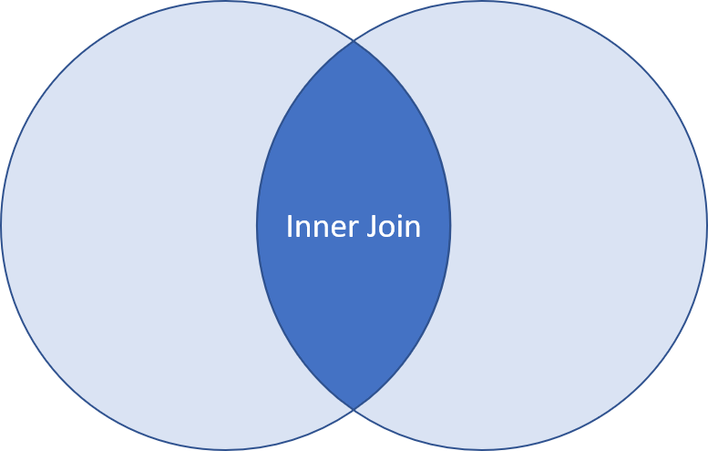

```r
set1 = merge(companies, countries, by="Country")
head(set1) # "The Netherlands" dropped, not matching with "Netherlands"
```

```
##     Country ï..Global.Rank                  Company Sales...billion.
## 1 Australia           1833      CFS Retail Property              0.8
## 2 Australia             44             BHP Billiton             72.2
## 3 Australia             58 National Australian Bank             49.2
## 4 Australia           1242               AGL Energy              7.6
## 5 Australia             40        Commonwealth Bank             47.8
## 6 Australia           1487                Crown Ltd              2.8
##   Profits...billion. Assets...billion. Market.Value...billion. Continent
## 1                0.4               8.6                     6.0   Oceania
## 2               15.4             129.3                   184.7   Oceania
## 3                4.2             791.3                    76.3   Oceania
## 4                0.1              14.5                     9.5   Oceania
## 5                7.3             735.2                   117.5   Oceania
## 6                0.5               5.9                     9.4   Oceania
##                  Location Population GDP_Per_Capita Life_Expectancy
## 1 (-25.274398,133.775136)   25088636          56352            82.8
## 2 (-25.274398,133.775136)   25088636          56352            82.8
## 3 (-25.274398,133.775136)   25088636          56352            82.8
## 4 (-25.274398,133.775136)   25088636          56352            82.8
## 5 (-25.274398,133.775136)   25088636          56352            82.8
## 6 (-25.274398,133.775136)   25088636          56352            82.8
```

Outer join:

- returns all rows from both companies and countries, joining records from companies which have matching keys in countries
- aka all countries from companies and contries data sets

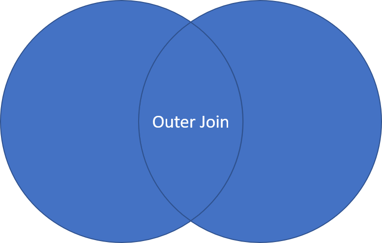

```r
set2 = merge(companies, countries, by="Country", all=T)
head(set2) # missing data filled with NA
```

```
##             Country ï..Global.Rank Company Sales...billion. Profits...billion.
## 1       Afghanistan             NA    <NA>               NA                 NA
## 2           Albania             NA    <NA>               NA                 NA
## 3           Algeria             NA    <NA>               NA                 NA
## 4            Angola             NA    <NA>               NA                 NA
## 5 Antigua & Barbuda             NA    <NA>               NA                 NA
## 6         Argentina             NA    <NA>               NA                 NA
##   Assets...billion. Market.Value...billion. Continent Location Population
## 1                NA                      NA      <NA>     <NA>   37209007
## 2                NA                      NA      <NA>     <NA>    2938428
## 3                NA                      NA      <NA>     <NA>   42679018
## 4                NA                      NA      <NA>     <NA>   31787566
## 5                NA                      NA      <NA>     <NA>     104084
## 6                NA                      NA      <NA>     <NA>   45101781
##   GDP_Per_Capita Life_Expectancy
## 1            544            60.5
## 2           5289            77.8
## 3           4238            75.6
## 4           3669            52.4
## 5          17636            76.4
## 6          11627            76.3
```

Left join:

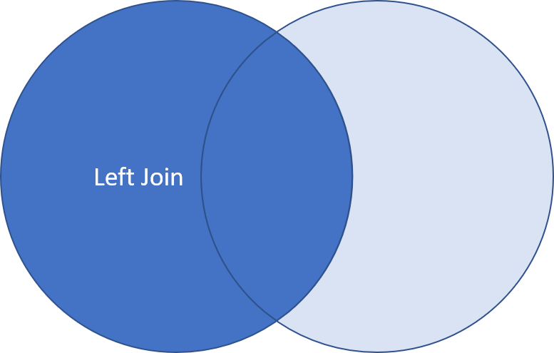

```r
set3 = merge(companies, countries, by="Country", all.x=T)
head(set3)
```

```
##     Country ï..Global.Rank                  Company Sales...billion.
## 1 Australia           1833      CFS Retail Property              0.8
## 2 Australia             44             BHP Billiton             72.2
## 3 Australia             58 National Australian Bank             49.2
## 4 Australia           1242               AGL Energy              7.6
## 5 Australia             40        Commonwealth Bank             47.8
## 6 Australia           1487                Crown Ltd              2.8
##   Profits...billion. Assets...billion. Market.Value...billion. Continent
## 1                0.4               8.6                     6.0   Oceania
## 2               15.4             129.3                   184.7   Oceania
## 3                4.2             791.3                    76.3   Oceania
## 4                0.1              14.5                     9.5   Oceania
## 5                7.3             735.2                   117.5   Oceania
## 6                0.5               5.9                     9.4   Oceania
##                  Location Population GDP_Per_Capita Life_Expectancy
## 1 (-25.274398,133.775136)   25088636          56352            82.8
## 2 (-25.274398,133.775136)   25088636          56352            82.8
## 3 (-25.274398,133.775136)   25088636          56352            82.8
## 4 (-25.274398,133.775136)   25088636          56352            82.8
## 5 (-25.274398,133.775136)   25088636          56352            82.8
## 6 (-25.274398,133.775136)   25088636          56352            82.8
```

Right join:

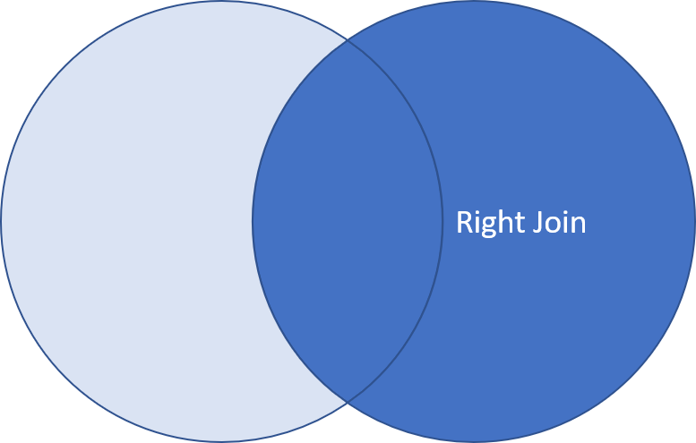

```r
set4 = merge(companies, countries, by="Country", all.y=T)
head(set4)
```

```
##             Country ï..Global.Rank Company Sales...billion. Profits...billion.
## 1       Afghanistan             NA    <NA>               NA                 NA
## 2           Albania             NA    <NA>               NA                 NA
## 3           Algeria             NA    <NA>               NA                 NA
## 4            Angola             NA    <NA>               NA                 NA
## 5 Antigua & Barbuda             NA    <NA>               NA                 NA
## 6         Argentina             NA    <NA>               NA                 NA
##   Assets...billion. Market.Value...billion. Continent Location Population
## 1                NA                      NA      <NA>     <NA>   37209007
## 2                NA                      NA      <NA>     <NA>    2938428
## 3                NA                      NA      <NA>     <NA>   42679018
## 4                NA                      NA      <NA>     <NA>   31787566
## 5                NA                      NA      <NA>     <NA>     104084
## 6                NA                      NA      <NA>     <NA>   45101781
##   GDP_Per_Capita Life_Expectancy
## 1            544            60.5
## 2           5289            77.8
## 3           4238            75.6
## 4           3669            52.4
## 5          17636            76.4
## 6          11627            76.3
```

## Native R

```r
attach(employees) # adds column names to search path
Position
```

```
## [1] "CEO"     "VF"      "Manager" "Clerk"
```

```r
detach(employees) # removes column names
# Position        # throws error
```